# Quantiful Internship Programme Assessment

Josh Atwal

25/08/2020

```r
retail <- read.csv('online_retail_II.csv')
retail$InvoiceDate <- as.Date(retail$InvoiceDate)
```

This analysis concerns a dataset of sales and returns collected over a period December 1st 2009 until December 9th 2011.

## *Exploratory analysis*

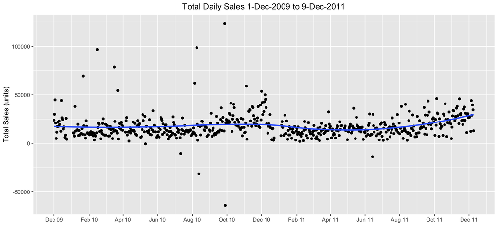

```r
retail %>% group_by(day=date(InvoiceDate), month=month(InvoiceDate)) %>%
        summarise(n=sum(Quantity)) %>%
        ggplot(aes(x=day,y=n)) +
        labs(x="Date",
             y="Total Sales (units)",
             title="Total Daily Sales 1-Dec-2009 to 9-Dec-2011", colour="Year") +
        geom_point() +
        geom_smooth(se = FALSE) +
        theme(plot.title = element_text(hjust = 0.5))+
        scale_x_date(NULL,
                     date_labels = "%b %y",
                     breaks = seq(as.Date("2009-12-1"), as.Date("2011-12-1"), by="2 month"))
```

Daily sales look fairly stable about a mean of 17.5k units per day with surges leading up to the holiday season. Negative outliers are present, relating to large returns or manual adjustments, but some positive outliers are also present.

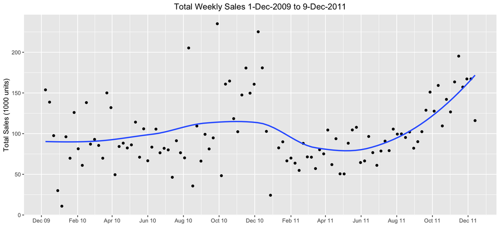

```r
# First extract the initial and final days of data collection
dateInit <- head(retail$InvoiceDate, 1)
dateFinal <- tail(retail$InvoiceDate, 1)
retail %>% mutate(cumWeek=interval(InvoiceDate[1], InvoiceDate) %/% weeks(1) + 1) %>% # Cumulative week variable
        group_by(cumWeek) %>%
        summarise(n=sum(Quantity)/1000) %>%
        ggplot(aes(x=retail$InvoiceDate[1] + weeks(cumWeek),y=n)) +
        labs(x="Month, Year",
             y="Total Sales (1000 units)",
             title="Total Weekly Sales 1-Dec-2009 to 9-Dec-2011", colour="Year") +
        geom_point() +
        geom_smooth(se = FALSE) +
        theme(plot.title = element_text(hjust = 0.5)) +
        scale_x_date(NULL, date_labels = "%b %y", breaks = seq(dateInit, dateFinal, by="2 month"))
```

Weekly sales show more clearly the trend of sales, with a surge followed by a dip observed over the 2010-11 holiday season. 2011 recovers from the dip similarly to the previous year at the same mid-year mark, but continues its growth upwards to a level higher than in the previous season.

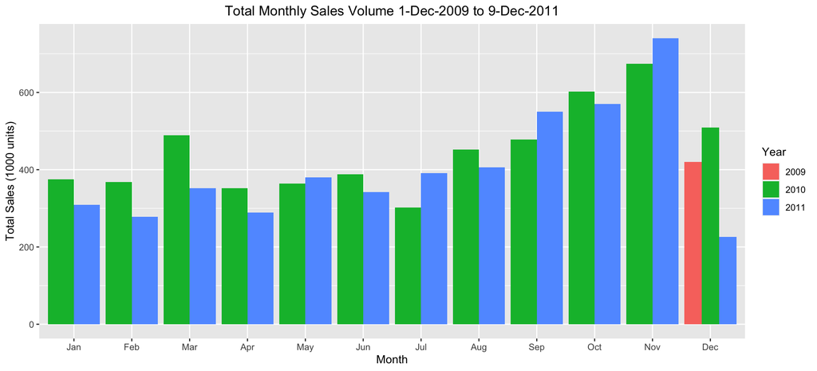

```r
retail %>% group_by(month=month(InvoiceDate, label=T, abbr=T),
                    Year=factor(year(InvoiceDate))) %>%
        summarise(n=sum(Quantity)/1000, .groups="drop") %>%
        ggplot(aes(x=factor(month),y=n, fill=Year)) +
        labs(x="Month",
             y="Total Sales (1000 units)",
             title="Total Monthly Sales Volume 1-Dec-2009 to 9-Dec-2011",
             colour="Year") +
        geom_bar(stat="identity",position=position_dodge()) +
        theme(plot.title = element_text(hjust = 0.5))
```

(Note that the dataset does not include sales for the whole month of Dec 2011, explaining the seeming under-performance.) As seen in the weekly sales plot, 2011 begins with a dip in sales below the level of 2010, however recovers to a higher level in the months leading up to December. It seems as though by December, a lot of people have already done their shopping and so this is the month we see sales begin to drop off.

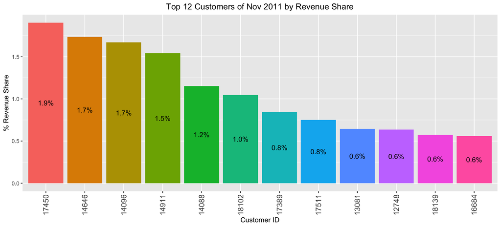

```r
currentDate <- tail(retail$InvoiceDate,1)
# Calculate share as proportion of total revenue
shares <- retail %>% filter(month(InvoiceDate)==month(currentDate)-1,
                            year(InvoiceDate)==year(currentDate)) %>%
            group_by(cust=factor(Customer.ID)) %>%
            summarise(Revenue=sum(Quantity*Price)) %>%
            mutate(share=100*Revenue/sum(Revenue))

shares %>%  arrange(desc(share)) %>%
            slice_head(n=13) %>%
            slice_tail(n=12) %>% # Remove missing customer ID
            ggplot(aes(x=reorder(cust, -share), y=share, fill=reorder(cust, -share))) +
            geom_bar(stat="identity") +
            geom_text(aes(label = scales::percent(round(share/100,3))),
                      position = position_stack(vjust = 0.5)) +
            theme(plot.title = element_text(hjust = 0.5),
                  axis.text.x  = element_text(angle=90, vjust=0.5, size=12)) +
            guides(fill=FALSE) +
            labs(x="Customer ID",
                 y="% Revenue Share",
                 title="Top 12 Customers of Nov 2011 by Revenue Share")
```